# Lab 1: Solution

David T. Frazier

30/08/2017

# OLS and Least Absolute Deviation (LAD) Regression

In this lab we will build and estimate linear models using the method of least absolute deviations (LAD). We will then comparing these results with those of standard OLS. This will require writing your own functions in R, pulling in the required data, and passing these bits to the `optim()` function in `R`.

Given a sample $(y_i,x_i),\; i=1,...,n$, from the population linear model
$$Y=\beta_0 +\beta_1 X_1 +\beta_2 X_2 +\cdots +\beta_p X_p +\epsilon,$$
the LAD regression estimates are obtained by solving the minimization problem:
$$\min_{b_0,...,b_p}\sum_{i=1}^{n}|y_i-b_0-b_1 x_{1i}-\cdots-b_p x_{pi}|.$$

## Lab Exercise

In this week’s lab we will analyze the relationship between income and food expenditures for a sample of Belgian households.

1. Load the dataset “engel.csv”. Visualize the relationship bewteen income (x-coordinate) and foodexp (y-coordinate)?

```r
engel_csv <- read_csv("engel.csv")
```

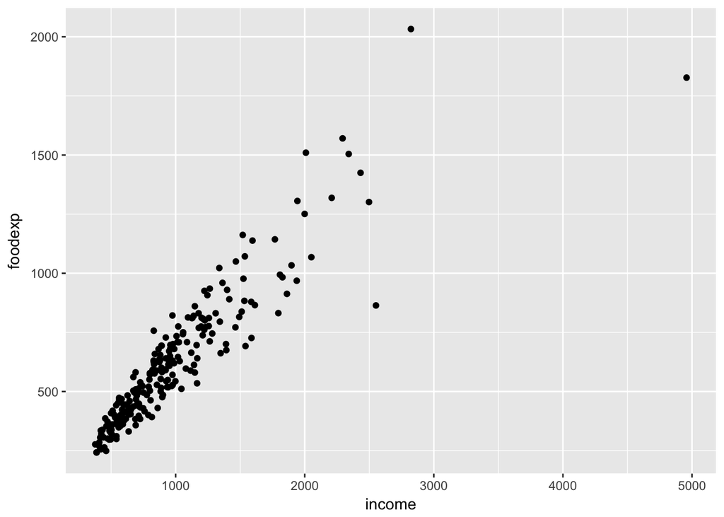

```r
ggplot(engel_csv, aes(x=income,y=foodexp)) + geom_point()
```

2. Using `optim()`, fit the linear regression model
   $$foodexp_i = \beta_0+\beta_1 income_i+\beta_2 income_i^2+\epsilon_i$$
   using the objective function
   $$f(b)={\sum_{i=1}^{n}(foodexp_{i}-b_0-b_1income_i-b_2income_i^2)^2}.$$
   Take as your starting values for the optimization `c(0,0,0)`.

[output not shown]

3. Now, fit the model using the `lm()` function. Compare these results with those obtained from your optimization program.

```r
fits_lm<- lm(foodexp~income+income2,data=engel_csv)
summary(fits_lm)
```

```
##
## Call:
## lm(formula = foodexp ~ income + income2, data = engel_csv)
##
## Residuals:
##     Min      1Q  Median      3Q     Max
## -525.99  -48.31    4.05   50.69  546.56
##
## Coefficients:
##               Estimate Std. Error t value Pr(>|t|)
## (Intercept)  8.006e+00  2.244e+01   0.357    0.722
## income       7.100e-01  3.083e-02  23.031  < 2e-16 ***
## income2     -6.603e-05  8.243e-06  -8.010 5.55e-14 ***
## ---
## Signif. codes:  0 '***' 0.001 '**' 0.01 '*' 0.05 '.' 0.1 ' ' 1
##
## Residual standard error: 101.2 on 232 degrees of freedom
## Multiple R-squared:  0.8671, Adjusted R-squared:  0.866
## F-statistic: 756.9 on 2 and 232 DF,  p-value: < 2.2e-16
```

4. Change the starting values in `optim()` to be `c(8,0,0)` and re-run the program. Compare the results with those obtained from the `lm()` function.

```r
model1 <- function(b, data) {
  b[1] + data$income * b[2]+data$income2 * b[3]
}

measure_distance2 <- function(mod, data) {
  diff <- data$foodexp - model1(mod, data)
  ((mean((diff )^2)))
}
bestOLS <- optim(c(8, 0,0), measure_distance2, data = engel_csv)
bestOLS$par
```

```
## [1]  8.614413e+00  7.092751e-01 -6.588344e-05
```

5. Questions c. and d. demonstrate that optimization is sometimes sensative to the choice of *initial values*. This is because `optim()` is what we call a local optimization method, in that the program seeks to optimize the objective function in a neighborhood of the starting value. In general, how could you attempt to solve this problem in practice?
6. What function shape would `optim()` would work well with? Can you list some examples.
7. Plot the residuals from `lm()` against the fitted values and comment on this relationship. Do there appear to be any visual outliers? HINT: use `?lm()` to see all of `lm()` options.
8. OLS is sensative to outliers since the objective function $f(b)$ behaves like a polynomial. A potential means of alleviating this issue is to instead estimate the regression model
   $$foodexp_i = \beta_0+\beta_1 income_i+\beta_2 income_i^2+\epsilon_i$$
   using least absolute deviations (LAD). Why might LAD be better behaved in the presence of outliers than OLS?
9. Using `optim()`, fit the linear regression model $foodexp_i = \beta_0+\beta_1 income_i+\beta_2 income_i^2+\epsilon_i$ using LAD. Compare the estimated coefficients with those obtained via OLS.

```r
# I basically did this in class, so I'm just posting the scripts here.

model1 <- function(b, data) {
  b[1] + data$income * b[2]+ data$income2 * b[3]
}

measure_distance3 <- function(mod, data) {
  diff <- data$foodexp - model1(mod, data)
  ((mean(abs(diff ))))
}
bestLAD <- optim(c(0, 0,0), measure_distance3, data = engel_csv)
bestLAD$par
```

```
## [1]  1.392196e-01  7.297367e-01 -7.285768e-05
```

10. Should we be concered with the starting value issue in `optim()` in the case of LAD regression? *ANS: Yes, optim will only return the global optima in cases where the objective function is globally concave or convex. What the results for different starting values tell us is that there may be regions where the objective function is not globally convex. This is an issue since optim will never leave this local optima.*
11. Implement one of the methods you discussed in part e. to determine if the estiated regression coefficients change for different starting values. *There are many different correct answers here. Just make sure they implement the ones the suggested in part e. For instance, if they suggested, try different starting values, make sure they tried several different starting values other than the ones I gave. If they said grid search, make sure they implemented it in R.*